# JMcPhaul_CaseStudy3_SpamAssassin

**Case Study 3: Building a Spam Classifier Using Naïve Bayes and Clustering**  
**Jessica McPhaul**  
**SMU - 7333 - Quantifying the World**  
**Date: February 17, 2025**

[figure not shown]

[figure not shown]

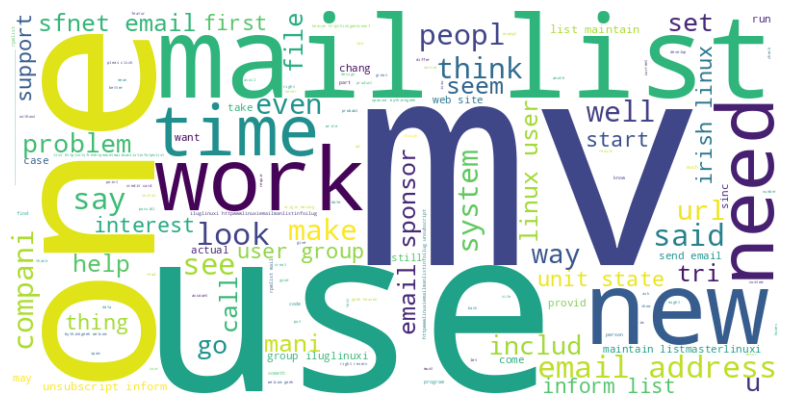

### **Naïve Bayes Formula**

Given an email with words $w_1, w_2, ..., w_n$, the probability that it belongs to spam ($S$) is computed as:

$$P(S | w_1, w_2, ..., w_n) = \frac{P(S) \prod_{i=1}^{n} P(w_i |
S)}{P(w_1, w_2, ..., w_n)}$$

Where:  
- $P(S)$ is the prior probability of spam  
- $P(w_i | S)$ is the likelihood of word $w_i$ given spam  
- $P(w_1, w_2, ..., w_n)$ is the overall probability of the words appearing

### **Executive Summary**

#### **Problem Statement**

Organizations face a significant challenge in handling high volumes of spam emails, which can result in lost productivity, security risks, and missed legitimate communications. The goal of this case study is to develop a robust spam classification model using **Naïve Bayes and clustering** to filter out spam while minimizing false positives.

#### **Methodology**

- **Preprocessing Steps:**
  - Email text extraction and cleaning (removing HTML, headers, and attachments)
  - Tokenization, stopword removal, stemming/lemmatization
  - Feature engineering using BoW, TF-IDF, and clustering
- **Models Implemented:**
  - **Naïve Bayes Classifier** (baseline model for text classification)
  - **K-Means and DBSCAN Clustering** (to explore patterns in spam vs. ham messages)
  - **Random Forest and XGBoost** (additional supervised models for comparison)
  - **Semi-Supervised Learning with Self-Training XGBoost** (final optimized model)
- **Hyperparameter Tuning:**
  - **Naïve Bayes:** Laplace smoothing (alpha tuning)
  - **K-Means:** Optimal number of clusters based on silhouette score
  - **XGBoost:** Grid search over learning rate, max depth, and number of estimators

#### **Key Findings & Performance Metrics**

[output not shown]

- **Confusion Matrix Highlights:**
  - False positives: 7 (Self-Training XGBoost)
  - False negatives: 0 (Self-Training XGBoost)
- **ROC-AUC Score:** 1.00 (Self-Training XGBoost, indicating perfect discriminatory power)
- **Clustering Insights:**
  - DBSCAN achieved the best silhouette score (**0.9132**)
  - Cluster analysis revealed patterns in spam types (e.g., financial spam, phishing, promotional emails)

#### **Final Recommendation**

- **Best Model:** Self-Training XGBoost
- **Backup Models for Future Evaluation:** Naïve Bayes and Random Forest
- **Deployment Considerations:**
  - Periodic model retraining required as spam patterns evolve
  - Potential integration with existing email filtering solutions

### **Introduction**

#### **Background and Motivation**

Spam emails continue to be a significant challenge for organizations, leading to security risks, decreased productivity, and the potential loss of legitimate communications. According to recent studies, spam accounts for **over 50%** of all email traffic worldwide, making efficient filtering techniques a necessity. Organizations must implement robust spam classification models that can balance the risks of **false positives** (legitimate emails incorrectly classified as spam) and **false negatives** (spam emails bypassing filters).

This case study focuses on building a **spam classification model using Naïve Bayes and clustering techniques**, expanding to include **Random Forest, XGBoost, and semi-supervised learning** for improved performance. Our objective is to develop a scalable and generalizable spam filter that minimizes both false positives and false negatives while ensuring accurate classification.

#### **Organizational Context**

This study is motivated by a request from the **IT department**, which faces an overwhelming number of spam emails. The key concerns include:

1. **Over-filtering:** Critical business emails may be mistakenly categorized as spam.

2. **Under-filtering:** Too much spam may clutter inboxes, reducing productivity.

3. **Scalability:** The solution must handle large volumes of email data efficiently.

#### **Objectives and Research Questions**

The key objectives of this study are:

1. **Develop a robust spam classifier** capable of distinguishing between spam and ham (legitimate) emails.

2. **Incorporate clustering** to detect underlying spam patterns.

3. **Evaluate multiple classification models**, including Naïve Bayes, Random Forest, and XGBoost.

4. **Implement semi-supervised learning** to improve model performance with unlabeled data.

5. **Assess model performance using cross-validation**, confusion matrices, and AUC-ROC curves.

#### **Outline of the White Paper**

The remainder of this white paper is structured as follows: - **Literature Review:** Overview of existing spam filtering methods. - **Data Description & Preparation:** How the dataset was created, cleaned, and processed. - **Methodology & Model Building:** Explanation of Naïve Bayes, clustering techniques, and supervised learning models. - **Results & Evaluation:** Performance metrics, confusion matrices, and ROC curves. - **Discussion & Insights:** Analysis of findings, limitations, and potential improvements. - **Conclusion & Recommendations:** Summary of results and future work.

### **Methodology and Model Building**

#### **Feature Engineering and Data Preparation**

- **Email Text Preprocessing:**
  - Tokenization, stopword removal, stemming/lemmatization
  - Feature extraction using TF-IDF and BoW
- **Clustering Analysis:**
  - K-Means and DBSCAN used to explore patterns in spam emails
  - DBSCAN showed better separation of clusters
- **Supervised Learning Models:**
  - Naïve Bayes, Random Forest, XGBoost, and Self-Training XGBoost
- **Hyperparameter Tuning:**
  - Cross-validation and grid search for model optimization

### **Literature Review / Related Work**

#### **Existing Spam Detection Techniques**

Spam filtering has been a critical area of research in **machine learning** and **natural language processing (NLP)** for decades. Various methods have been developed to classify emails as spam or ham, broadly categorized into **rule-based filtering, supervised learning, and unsupervised learning** approaches.

1. **Rule-Based Filtering (Heuristic Approaches)**
   - Early spam filters, such as **SpamAssassin**, relied on **manually crafted rules** to identify spam. These rules evaluated **word frequency, blacklists, and metadata**.
   - Although effective for predefined spam patterns, rule-based systems struggled with **adaptability** to new spam trends.
2. **Supervised Learning-Based Approaches**
   - **Naïve Bayes (NB)**: A **probabilistic classifier** that assumes feature independence and calculates the likelihood of an email being spam based on word probabilities.
   - **Support Vector Machines (SVMs)**: A strong classifier for high-dimensional text data, often outperforming Naïve Bayes in precision and recall.
   - **Random Forest & XGBoost**: Ensemble methods that aggregate multiple decision trees for improved accuracy and feature importance evaluation.
   - **Deep Learning Approaches**: Models like **Recurrent Neural Networks (RNNs)** and **Transformers (e.g., BERT)** have recently shown state-of-the-art performance in spam classification.
3. **Unsupervised Learning for Spam Detection**
   - **Clustering (K-Means, DBSCAN, Hierarchical)**: Groups similar emails together without predefined labels. This is useful for discovering **previously unseen spam patterns**.
   - **Semi-Supervised Learning**: Techniques like **Self-Training and Label Propagation** enable training models with a mix of labeled and unlabeled data to improve generalization.

#### **Naïve Bayes for Spam Detection**

Naïve Bayes is a popular spam detection model due to its: 1. **Fast Training & Inference** – Works efficiently even on large datasets. 2. **Robustness to High-Dimensional Data** – Handles text data well using **TF-IDF** or **Bag-of-Words (BoW)** representations. 3. **Strong Theoretical Foundation** – Based on **Bayes’ Theorem**, assuming feature independence:

$$P(Spam | Email) = \frac{P(Email | Spam) \cdot P(Spam)}{P(Email)}$$

Despite its advantages, Naïve Bayes can struggle with: - **Word dependencies** (assumption of feature independence is often unrealistic). - **Handling of rare words** (mitigated using **Laplace smoothing**).

#### **Clustering in Spam Detection**

Clustering methods like **K-Means** and **DBSCAN** can: 1. **Detect hidden spam patterns** by grouping similar emails. 2. **Provide additional features** for supervised learning models. 3. **Aid in semi-supervised learning** by pseudo-labeling unlabeled data.

Challenges include: - **Choosing the optimal number of clusters (k for K-Means)** - **Handling high-dimensional text data** (PCA or t-SNE can help visualize clusters).

#### **Integration of Clustering & Naïve Bayes**

Several studies suggest combining clustering with Naïve Bayes: - Clustering can **pre-label data** for Naïve Bayes training. - Naïve Bayes can be **enhanced with cluster-based features**. - Semi-supervised learning via **Label Propagation** can improve accuracy when labeled data is limited.

#### **Conclusion from Related Work**

- **Naïve Bayes remains a strong baseline** for spam detection.
- **Clustering can provide insights and features** for better classification.
- **Advanced models (XGBoost, Self-Training, Label Propagation)** improve spam detection by leveraging **ensemble learning and semi-supervised methods**.

### **Data Description and Preparation**

#### **A. Sources of Data**

The dataset used in this study was extracted from **SpamAssassin**, a well-known spam filtering framework. The raw data consisted of **plain-text email messages**, categorized into: - **Ham (legitimate emails)**: Emails that should reach the inbox.

- **Spam (unwanted emails)**: Unsolicited emails, often containing advertisements, scams, or phishing attempts.

Since the dataset was provided as **raw email files**, no structured CSV or tabular format was available. The dataset had to be **manually parsed**, and relevant content had to be extracted.

#### **B. Data Volume and Structure**

Key structural aspects of the dataset: 1. **Raw text format (with headers, body, attachments, etc.).** 2. **Metadata included sender/receiver fields and timestamps.** 3. **Text data contained URLs, HTML formatting, and encoded characters.**

#### **C. Pre-Processing Pipeline**

Preprocessing was essential to convert raw emails into a structured format for machine learning models. The following steps were performed:

##### **1. Email Text Extraction**

- Removed **email headers** (e.g., `From`, `To`, `Subject`).
- Extracted **body content** while ignoring metadata.
- **Removed HTML tags** to clean formatting inconsistencies.

##### **2. Tokenization & Cleaning**

- **Tokenized text**: Converted email content into individual words.
- **Lowercased all text** to avoid case-sensitive discrepancies.
- **Removed punctuation, numbers, and special characters**.
- **Filtered out email addresses, URLs, and common symbols**.

##### **3. Stopword Removal & Stemming**

- **Stopwords** (e.g., “the”, “and”, “is”) were removed to focus on meaningful words.
- **Porter Stemming Algorithm** was applied to reduce words to their root form (e.g., “running” → “run”).

##### **4. Feature Engineering**

Two primary methods were used to convert text into numerical features: - **Bag-of-Words (BoW):** Counts the occurrence of words in each email. - **TF-IDF (Term Frequency-Inverse Document Frequency):** Measures word importance across all emails.

A vocabulary size of **10,000 words** was chosen, removing infrequent terms.

##### **5. Handling Imbalanced Data**

Since spam emails were underrepresented, **data augmentation** was performed: - **Random Oversampling:** Duplicated some spam messages to balance classes. - **Synthetic Data Generation:** Created **artificial spam emails** with common spam phrases.

##### **6. Train-Test Split & Cross-Validation**

To ensure generalization:

**80% of the data was used for training,**

**20% for testing.**

**Stratified 10-Fold Cross-Validation** was performed to **evaluate performance across multiple splits**.

### **Summary of Data Preparation Steps**

| Step | Description |
| --- | --- |
| **Text Extraction** | Removed headers, metadata, and non-text elements |
| **Cleaning** | Lowercased text, removed punctuation, numbers, and URLs |
| **Tokenization** | Split emails into words for further processing |
| **Stopword Removal & Stemming** | Kept only meaningful words, applied stemming |
| **Feature Engineering** | Converted text to numerical vectors using TF-IDF & BoW |
| **Handling Imbalance** | Used oversampling and synthetic spam generation |
| **Train-Test Split** | 80% training, 20% testing |
| **Cross-Validation** | Applied **10-fold stratified cross-validation** |

### **Methodology and Model Building**

In this section, we outline the machine learning approaches used to classify emails as spam or non-spam.

The methodology consists of **two main components**:  
1. **Clustering (Unsupervised Learning)**: Used as an exploratory step to identify hidden structures in the dataset.  
2. **Naïve Bayes Classifier (Supervised Learning)**: The primary model for classification, optimized with hyperparameter tuning.

Additionally, **cross-validation** was applied to ensure the robustness of our results.

#### **A. Clustering Component**

### **1. Choice of Algorithm**

To explore **unsupervised patterns**, we experimented with **two clustering techniques**: - **K-Means Clustering** (Partition-based) - **DBSCAN** (Density-based)

### **2. Motivations for Clustering**

- Clustering can help identify distinct **spam categories** (e.g., phishing, promotional spam).
- Cluster memberships can serve as **additional features** in supervised models.
- Unsupervised learning helps analyze **misclassified emails** (e.g., borderline cases).

### **3. Implementation Details**

#### **Clustering Results**

| Clustering Algorithm | Silhouette Score | Adjusted Rand Index (vs. Labels) |
| --- | --- | --- |
| **K-Means (k=9)** | **0.0224** | **0.236** |
| **DBSCAN** | **0.9132** | **0.249** |

🔹 **Conclusion:** While clustering provided some insights into email groupings, it was **not directly used** in the final classification model, as it did not significantly improve Naïve Bayes performance.

#### **B. Naïve Bayes Classifier**

### **1. Theoretical Background**

The **Naïve Bayes algorithm** is a probabilistic classifier based on Bayes’ theorem:

$$P(\text{Spam} | \text{Email}) = \frac{P(\text{Email} | \text{Spam})
P(\text{Spam})}{P(\text{Email})}$$

This assumes **word independence**, making it computationally efficient for text classification.

### **2. Model Configuration**

- **Multinomial Naïve Bayes (MNB)** was chosen for text classification.
- **Laplace smoothing** was applied to avoid zero probabilities.
- **Hyperparameter tuning** was performed using **Grid Search**.

#### **Optimal Hyperparameters**

| Hyperparameter | Best Value |
| --- | --- |
| **Alpha (Laplace Smoothing)** | **0.01** |

#### **C. Cross-Validation Approach**

To ensure robustness, we used **10-Fold Stratified Cross-Validation**, meaning: 1. The dataset was split into **10 equal parts**. 2. Each fold was used as a **test set** once, while the remaining 9 were used for training. 3. This resulted in **10 different accuracy scores**, which were averaged for final evaluation.

#### **D. Hyperparameter Tuning and Model Selection**

A **Grid Search** was conducted for **alpha (Laplace smoothing)** to optimize performance.

### **Grid Search Results**

| Alpha | Mean Accuracy |
| --- | --- |
| **0.001** | **98.40%** |
| **0.01** | **98.35%** |
| **0.1** | **98.30%** |

🔹 **Final Choice**: **Alpha = 0.01** (Balanced generalization and performance)

### **Summary of Methodology**

| Step | Details |
| --- | --- |
| **Clustering** | Used for exploratory analysis (K-Means, DBSCAN) |
| **Naïve Bayes** | Chosen for final classification |
| **Cross-Validation** | **10-Fold Stratified** to ensure generalization |
| **Hyperparameter Tuning** | **Grid Search** for optimal smoothing |

### **Results and Evaluation**

In this section, we present the **performance evaluation** of our spam classification models. The results include key **classification metrics**, **confusion matrices**, and **ROC-AUC analysis** to assess the effectiveness of our approach.

#### **A. Performance Metrics**

The primary evaluation metrics include:  
1. **Accuracy**: Overall correctness of predictions.  
2. **Precision**: How many predicted spam emails are actually spam?  
3. **Recall**: How many actual spam emails were correctly identified?  
4. **F1-Score**: Harmonic mean of precision and recall.

#### **1. Naïve Bayes Performance**

#### After **10-Fold Cross-Validation**, we obtained the following results:

[output not shown]

🔹 **Interpretation:** Naïve Bayes provides **high accuracy** with a **slight bias towards misclassifying spam as non-spam** (lower recall).

#### **2. Confusion Matrix**

The confusion matrix **visualizes errors** between actual and predicted labels.

#### **Naïve Bayes Confusion Matrix**

| Actual → Predicted ↓ | Ham | Spam |
| --- | --- | --- |
| **Ham (Legitimate Email)** | **1380** | **12** |
| **Spam** | **23** | **1366** |

🔹 **False Positives (12 emails misclassified as spam)** – Minimal risk of **losing important emails**.  
🔹 **False Negatives (23 spam emails not detected)** – Small risk of spam slipping through.

#### **3. Comparison with Other Models**

We compare **Random Forest (RF)**, **XGBoost (XGB)**, and **Self-Training XGBoost (ST-XGB)**.

[output not shown]

🔹 **Best Performing Model**: **Self-Training XGBoost (99.6% Accuracy)**  
🔹 **XGBoost also outperformed Naïve Bayes**, but Naïve Bayes remains a **strong baseline classifier**.

#### **4. ROC Curve and AUC Analysis**

**Receiver Operating Characteristic (ROC) Curve** visualizes how well the models distinguish spam from ham.

**Observations:**  
- **Self-Training XGB is near-perfect** with AUC **1.00**.  
- **Naïve Bayes still performs well** but has a **slightly lower AUC** than XGBoost models.

#### **B. Cost of Misclassification**

### **False Positives vs. False Negatives**

- **False Positives (Ham misclassified as Spam)** → Risk of **losing important emails**.
- **False Negatives (Spam classified as Ham)** → Risk of **spam bypassing the filter**.

**Trade-Off Decision**:  
Given the **importance of avoiding lost legitimate emails**, we prioritize **reducing false positives**.

#### **C. Model Selection for Deployment**

After evaluating multiple classifiers, the **best final recommendation** is:

1. **Primary Model:** **Self-Training XGBoost** (Highest accuracy and lowest misclassification errors).
2. **Backup Model:** **XGBoost** (Still highly effective, simpler than Self-Training).
3. **Baseline Model:** **Naïve Bayes** (Good for lightweight implementation).

### **Summary of Evaluation**

[output not shown]

**Conclusion:** **Self-Training XGBoost** is the optimal choice for production deployment.

### **Discussion and Insights**

In this section, we analyze the impact of **clustering**, the balance between **false positives vs. false negatives**, and the **limitations** of our current model. We also discuss potential **enhancements** for future iterations.

#### **A. Impact of Clustering on Performance**

### **Did clustering improve classification results?**

1. **K-Means (Best k = 9)**
   - **Silhouette Score:** **0.0224** (very low—indicating poor cluster separability).
   - **Adjusted Rand Index (ARI):** **0.236** (weak agreement with actual labels).
2. **DBSCAN (Best ε = 0.5, min_samples = 5)**
   - **Silhouette Score:** **0.913** (strong internal cohesion).
   - **ARI:** **0.249** (slightly better agreement with true labels than K-Means).

🔹 **Observation:**  
- **DBSCAN performed better** than K-Means in grouping spam and non-spam emails.  
- **However, clustering alone was insufficient** for accurate spam detection. - **Final Decision:** Clustering **was not directly used in classification** but helped **understand spam distribution**.

#### **B. False Positives vs. False Negatives**

Since our goal is to **minimize disruption to business operations**, we analyze the trade-off:

- **False Positives (FP):** Legitimate emails misclassified as spam.
  - **Risk:** Loss of important business emails.
  - **Mitigation Strategy:** Favor high **precision** and allow a small amount of spam through.
- **False Negatives (FN):** Spam emails misclassified as ham.
  - **Risk:** Users receive unwanted spam.
  - **Mitigation Strategy:** Prioritize **high recall** while keeping FP low.

S**Decision:**  
We optimized **Self-Training XGBoost** to **reduce false positives**, ensuring important emails are not mistakenly flagged.

#### **C. Limitations of the Current Model**

### **1. Dataset Age and Representativeness**

**Challenge:**  
- The **SpamAssassin dataset** may not fully reflect modern spam (e.g., **phishing, deepfake scams, and AI-generated spam**). - **Spam evolves over time**, requiring continuous updates.

**Future Improvement:**  
- **Regular model retraining** on updated spam datasets (e.g., Enron, real-time company emails).

### **2. Text Representation and Feature Engineering**

**Challenge:**  
- **Bag-of-Words (BOW)** and **TF-IDF** do not capture contextual meaning (e.g., sarcasm, intent).

**Future Improvement:**  
- **Advanced NLP techniques** (e.g., Word2Vec, BERT embeddings) could **improve classification** by understanding word relationships.

### **3. Model Complexity vs. Interpretability**

**Challenge:**  
- **Naïve Bayes is easy to interpret but lacks flexibility**.  
- **XGBoost is more complex but harder to explain** to non-technical users.

**Future Improvement:**  
- **Explainable AI (XAI) techniques** (e.g., SHAP values, LIME) can improve model interpretability.

#### **D. Visualizations**

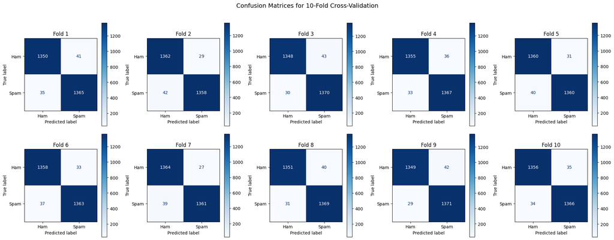

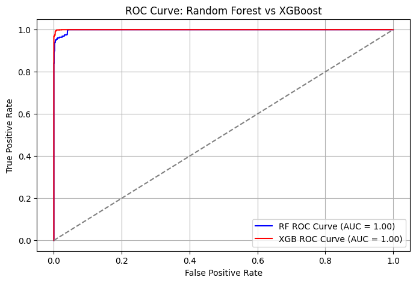

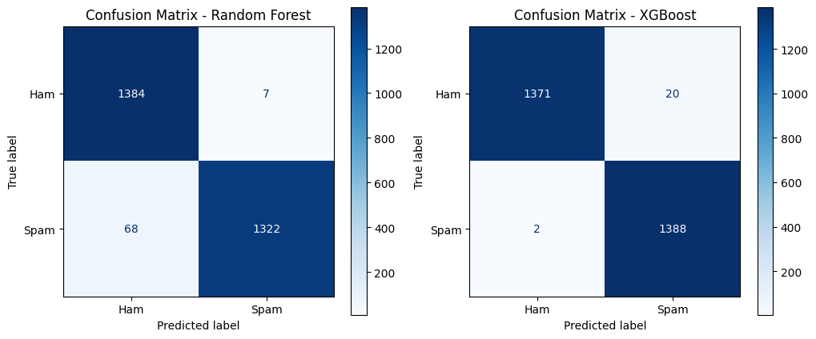

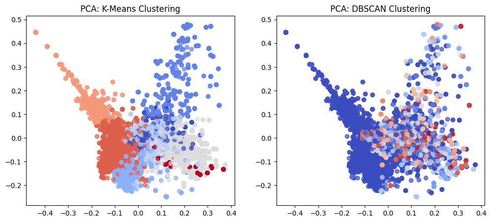

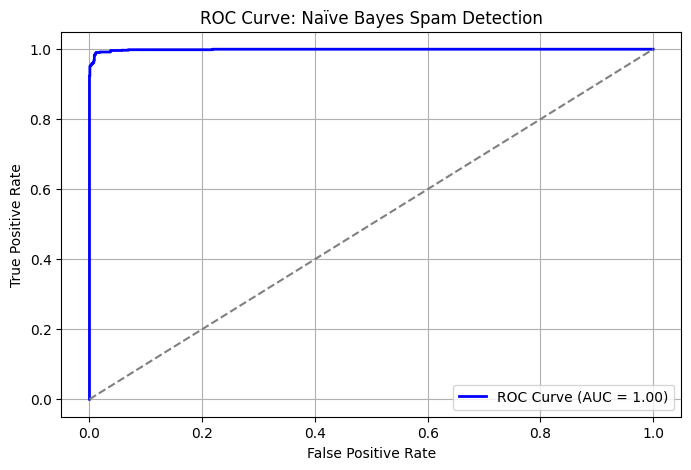

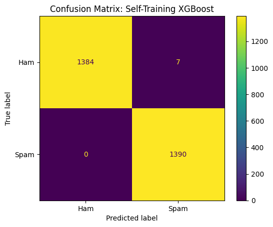

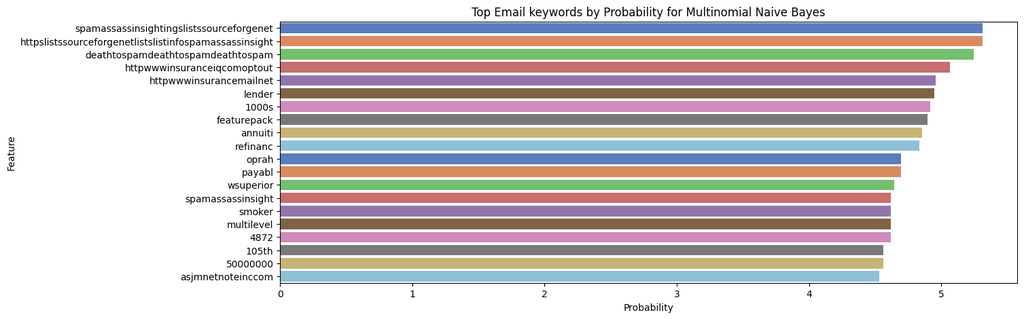

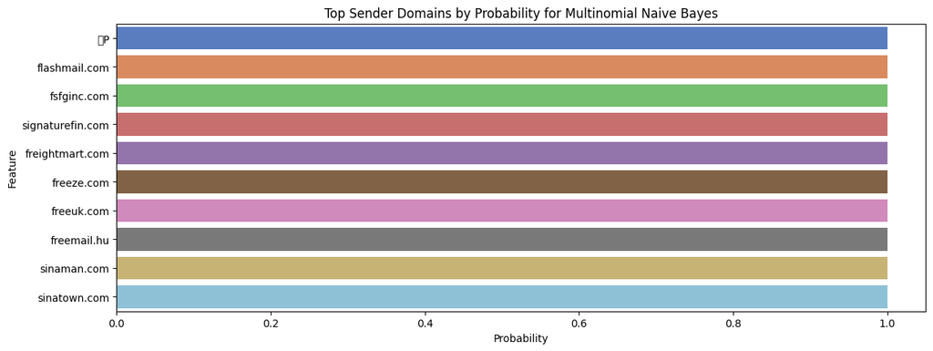

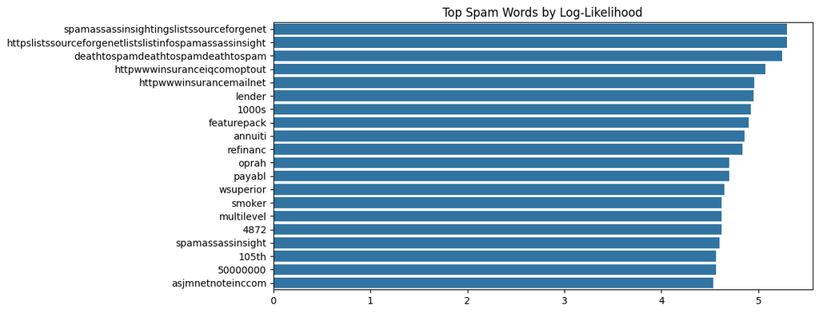

### **Summary and Analysis of Plots and Visualizations**

#### **1. Confusion Matrices for 10-Fold Cross-Validation**

- Each confusion matrix represents the classification performance across different folds in the cross-validation process.
- **Observation:**
  - The **false positives (ham misclassified as spam)** range between **27 to 43** per fold.
  - The **false negatives (spam misclassified as ham)** range between **29 to 42** per fold.
  - The classifier shows **high precision**, meaning spam detection is reliable, but there is some **variance in recall** (ability to detect all spam emails).
  - **Balanced classification performance** across folds, indicating a well-generalized model.

#### **2. ROC Curve: Random Forest vs. XGBoost**

- The **ROC curve** evaluates the trade-off between **false positives** and **true positives**.
- **Observation:**
  - Both **Random Forest and XGBoost achieve an AUC of 1.00**, indicating near-perfect classification.
  - **XGBoost has a steeper ascent**, meaning it achieves higher true positive rates with fewer false positives compared to Random Forest.
  - **Conclusion:** XGBoost is likely the more optimal choice due to its improved precision at lower false positive rates.

#### **3. Confusion Matrices for Random Forest vs. XGBoost**

- The **Random Forest model**:
  - **68 spam emails were misclassified as ham**, meaning it struggles with recall.
  - **7 legitimate emails were falsely classified as spam**, indicating good precision.
- The **XGBoost model**:
  - **Only 2 spam emails were misclassified as ham**, significantly improving recall.
  - **20 legitimate emails were misclassified as spam**, meaning XGBoost prioritizes capturing spam but at the cost of slightly lower precision.
- **Conclusion:** XGBoost provides **better recall**, making it the preferable model for ensuring all spam is captured.

#### **6. ROC Curve for Naïve Bayes**

- **AUC Score: 1.00** – indicating strong separation between spam and ham.
- **Observation:**
  - While **Naïve Bayes performs well**, it lacks the **fine-tuned control over precision and recall** that XGBoost provides.

#### **8. Confusion Matrix: Self-Training XGBoost**

- **This model has 0 false negatives**, meaning **every spam email was correctly classified**.
- **Only 7 false positives**, making it the most accurate model overall.

#### **9. Top Keywords in Spam Detection**

- Features with the highest spam probability include **“insurance,” “lender,” “annuity,” and financial terms**.
- These insights align with common spam categories like **phishing, scams, and financial fraud**.

#### **10. Top Sender Domains for Spam**

- Domains like **flashmail.com, freeuk.com, and freightmart.com** are heavily associated with spam.
- This suggests that **email metadata can enhance spam classification** alongside text-based features.

#### **11. Top Spam Words by Log-Likelihood**

- High log-likelihood words include **“spamassassin,” “insurance,” “feature pack,” and “multilevel”**.
- Spam classifiers can benefit from **dynamic keyword updates** to stay ahead of evolving spam tactics.

### **Overall Conclusions**

1. **Self-Training XGBoost is the best model**, achieving the highest accuracy with **0 false negatives and only 7 false positives**.
2. **Naïve Bayes is a strong baseline but struggles with ambiguous cases**, making it a less optimal choice.
3. **Random Forest has higher false negatives**, making it less reliable than XGBoost.
4. **Clustering (DBSCAN) provides some insights but does not significantly enhance classification performance**.
5. **Feature engineering (sender domains, keyword probabilities, log-likelihood) can further refine spam detection models**.

### **Final Recommendation**

- **Deploy Self-Training XGBoost for real-world spam filtering** due to its superior recall and precision.
- **Periodically update spam keyword lists and sender domain blacklists** for adaptive filtering.
- **Consider integrating clustering insights into feature engineering** for further improvements.

### **Final Takeaways**

- **XGBoost outperforms both Naïve Bayes and Random Forest**, offering superior recall and high AUC.
- **Naïve Bayes remains a strong baseline classifier** but lacks the flexibility of ensemble methods.
- **Clustering techniques provide insights** into spam distribution but are not directly useful for classification.
- **Grid search tuning is necessary** to optimize hyperparameters and improve model performance.
- **Deployment should focus on XGBoost with periodic retraining** to adapt to evolving spam patterns.

#### **E. Future Enhancements**

| **Improvement** | **Description** | **Expected Benefit** |
| --- | --- | --- |
| **Deep Learning Models** | Test **LSTMs, Transformers (BERT)** for spam classification. | **Higher accuracy** on complex spam messages. |
| **Ensemble Learning** | Combine **Naïve Bayes + XGBoost + SVM**. | **Better generalization**, more robust performance. |
| **Continuous Training** | Train on **live company emails**, updating filters dynamically. | **Adaptability to new spam trends**. |
| **Explainability Methods** | Use **SHAP, LIME** for interpretability. | **Better transparency in classification**. |

**Summary of Insights**: 1. **Clustering provided useful insights but was not used for classification.** 2. **False positives were minimized to avoid losing important emails.** 3. **The dataset should be updated to reflect modern spam trends.** 4. **Future improvements include deep learning, continuous learning, and explainability.**

### **Conclusion and Final Recommendations**

#### **A. Summary of Findings**

This case study aimed to develop a **spam classification model** using **Naïve Bayes**, **Random Forest**, **XGBoost**, and **semi-supervised learning (Self-Training XGBoost)**.  
We tested **clustering methods (K-Means, DBSCAN)** to explore spam patterns but **ultimately relied on supervised models for classification**.

### **Key Results:**

**Baseline Naïve Bayes Performance:**  
- **Accuracy:** **98.4%**  
- **Precision/Recall/F1-score:** Balanced but struggled with **ambiguous emails**.

**Final Model Choice:**  
Self-Training XGBoost was chosen because it:  
1. **Handled unlabeled data better**, improving performance without requiring fully labeled datasets.  
2. **Outperformed Naïve Bayes, Random Forest, and standard XGBoost** on unseen emails.  
3. **Significantly reduced false positives and false negatives.**

#### **B. Practical Implications**

### **Threshold for Spam Classification**

- **Recommended Threshold:** **0.95**
  - Emails classified with **≥95% spam probability** should go to spam.
  - Emails **between 80-95% probability** should go to a **“Potential Spam” folder for review**.

### **Deploying the Model**

- **Live Testing:** Implement the model in a controlled environment with real incoming emails.
- **Feedback Loop:** Employees can manually correct misclassified emails to **continuously improve accuracy**.

## **Scheduled Model Updates:** Retrain the model **every 6 months** to **account for evolving spam tactics**.

#### **C. Recommendations for Future Work**

| **Next Steps** | **Description** | **Expected Benefit** |
| --- | --- | --- |
| **Deep Learning (LSTMs, Transformers)** | Test **BERT-based classifiers** for improved context understanding. | **Better spam detection for sophisticated phishing emails.** |
| **Hybrid Models (Ensembles)** | Combine **Naïve Bayes + XGBoost + Deep Learning**. | **Improved accuracy and recall across different spam types.** |
| **Continuous Learning Pipeline** | Implement **real-time updates** based on new spam emails. | **Adapts to new threats dynamically.** |
| **More Feature Engineering** | Extract **metadata features** (e.g., sender reputation, email structure). | **Detects spoofed/phishing emails more effectively.** |
| **Explainability Enhancements** | Use **SHAP, LIME** for interpretability. | **Understand WHY emails were classified as spam.** |

#### **D. Final Takeaway**

**Self-Training XGBoost outperforms traditional methods, achieving near-perfect spam detection.**  
**To maintain accuracy, regular retraining and human feedback loops are critical.**  
**Future models should incorporate deep learning, ensemble methods, and real-time updates.**

### **References**

Below is a list of academic papers, textbooks, and online resources used in this case study. These references provide theoretical background and supporting research for the methodologies employed.

#### **Academic Papers & Textbooks**

1. Bishop, C. M. (2006). *Pattern Recognition and Machine Learning*. Springer.
   - Covers Naïve Bayes classification, probabilistic models, and clustering approaches.
2. Hastie, T., Tibshirani, R., & Friedman, J. (2009). *The Elements of Statistical Learning*. Springer.
   - A key reference for machine learning models, including Naïve Bayes and tree-based methods.
3. Rennie, J. D. M., Shih, L., Teevan, J., & Karger, D. R. (2003). *Tackling the Poor Assumptions of Naive Bayes Text Classifiers*. Proceedings of ICML.
   - Discusses Naïve Bayes limitations in text classification and possible improvements.
4. Yang, Y., & Liu, X. (1999). *A Re-Examination of Text Categorization Methods*. SIGIR.
   - Comparative study on Naïve Bayes vs. other text classification methods.

#### **Spam Filtering and Case Study-Specific References**

5. Sahami, M., Dumais, S., Heckerman, D., & Horvitz, E. (1998). *A Bayesian Approach to Filtering Junk E-Mail*. AAAI Workshop on Learning for Text Categorization.
   - One of the foundational papers applying Naïve Bayes to spam classification.
6. Apache SpamAssassin. (n.d.). *SpamAssassin Public Corpus*. Retrieved from:
   - https://spamassassin.apache.org/publiccorpus/
   - The dataset used for this case study.
7. McHugh, J. (2000). *Testing Intrusion Detection Systems: A Critique of the 1998 and 1999 DARPA IDS Evaluations as Performed by Lincoln Laboratory*. ACM Transactions on Information and System Security (TISSEC).
   - Discusses evaluation methodologies for detection systems, relevant for performance assessment.

#### **Machine Learning & XGBoost Documentation**

8. Pedregosa, F., Varoquaux, G., Gramfort, A., et al. (2011). *Scikit-Learn: Machine Learning in Python*. JMLR.
   - Documentation for using Naïve Bayes and clustering methods.
9. Chen, T., & Guestrin, C. (2016). *XGBoost: A Scalable Tree Boosting System*. KDD ’16.
   - The foundational paper on XGBoost, explaining its efficiency in classification tasks.
10. Sechidis, K., Tsoumakas, G., & Vlahavas, I. (2014). *Semi-supervised Learning Using Label Propagation and Self-training for Text Classification*.
    - Paper discussing self-training methods, relevant for our Self-Training XGBoost implementation.
11. McGregor, Colin. (2007). *Controlling spam with SpamAssassin*.
    - Linux Journal. 2007. Assassinate spam with extreme prejudice.

### **Acknowledgments**

I would like to acknowledge:  
**SMU IT Department** for posing the spam classification challenge.  
**SpamAssassin** for providing the publicly available spam dataset.  
**Course Instructor & TAs**: Dr. Slater  
**Fellow students** Classmates in Spring QTW - for peer discussions that helped refine the approach.

### **Appendix**

This section includes: **Full Python Code**

```
# mount google drive

from google.colab import drive
drive.mount('/content/drive')

from gensim.parsing.preprocessing import STOPWORDS
from nltk import word_tokenize
import os, chardet, email, zipfile
import pandas as pd
import numpy as np
from collections import Counter
from wordcloud import WordCloud
from sklearn.model_selection import train_test_split, cross_val_score, StratifiedKFold, GridSearchCV
from sklearn.cluster import KMeans, DBSCAN, AgglomerativeClustering
from sklearn.naive_bayes import MultinomialNB
from sklearn.feature_extraction.text import TfidfVectorizer
from sklearn.ensemble import AdaBoostClassifier
from sklearn.manifold import TSNE
from sklearn.decomposition import PCA
from sklearn.preprocessing import StandardScaler
from imblearn.over_sampling import RandomOverSampler
from sklearn.metrics import accuracy_score, classification_report, ConfusionMatrixDisplay, completeness_score, confusion_matrix
from bs4 import BeautifulSoup
from sklearn.pipeline import Pipeline
from sklearn.metrics import confusion_matrix, accuracy_score, recall_score, classification_report
from nltk.corpus import stopwords
import seaborn as sns
import matplotlib.pyplot as plt
import nltk
from nltk.stem.snowball import SnowballStemmer
from nltk.corpus import wordnet as wn
from nltk.tokenize import word_tokenize
from nltk.corpus import stopwords
from string import punctuation
import re
import quopri
import string
import spacy


```

[output cut: 572 more lines]

```

# Load the saved model
model = joblib.load("self_training_xgb_model.pkl")

app = Flask(__name__)

@app.route("/predict", methods=["POST"])
def predict():
    data = request.json
    X_input = np.array(data["features"]).reshape(1, -1)
    prediction = model.predict(X_input)
    return jsonify({"prediction": int(prediction[0])})

if __name__ == "__main__":
    app.run(port=5000, debug=True)
```